# Homework 11

2026-03-02

## Instructions

Answer the following questions and complete the exercises in RMarkdown. Please embed all of your code and push your final work to your repository. Your final lab report should be organized, clean, and run free from errors. Remember, you must remove the `#` for the included code chunks to run. Be sure to add your name to the author header above. For any included plots, make sure they are clearly labeled. You are free to use any plot type that you feel best communicates the results of your analysis.

Make sure to use the formatting conventions of RMarkdown to make your report neat and clean!

## Load the libraries

```r
library(tidyverse)
```

```r
options(scipen = 999)
```

## Data

For this homework, we are going to use the [Gapminder](https://www.gapminder.org/data/) data on population (pop), GDP per capita (gdp), and life expectancy (lex). These data were downloaded and compiled using the `gapminder_compile.Rmd` script in the data folder.

Let’s focus our attention on data from the past 100 years, between 1925 and 2025.

```r
gapminder <- read_csv("data/gapminder.csv") %>%
  filter(between(year, 1925, 2025))
```

1. Use the function(s) of your choice to get an idea of the overall structure of the data, including its dimensions, column names, classes, etc.

```r
dim(gapminder)
```

```
## [1] 19695     5
```

```r
names(gapminder)
```

```
## [1] "country" "year"    "pop"     "gdp"     "lex"
```

```r
glimpse(gapminder)
```

```
## Rows: 19,695
## Columns: 5
## $ country <chr> "Afghanistan", "Afghanistan", "Afghanistan", "Afghanistan", "A…
## $ year    <dbl> 1925, 1926, 1927, 1928, 1929, 1930, 1931, 1932, 1933, 1934, 19…
## $ pop     <dbl> 8748779, 8289705, 7854721, 7442562, 7121951, 6888085, 6736411,…
## $ gdp     <dbl> 1113.793, 1127.866, 1142.117, 1156.548, 1171.161, 1185.959, 12…
## $ lex     <dbl> 38.87, 39.01, 39.16, 39.30, 39.44, 39.59, 39.73, 39.88, 40.02,…
```

2. How many countries are represented in this dataset?

```r
gapminder %>%
  summarize(n_countries = n_distinct(country))
```

```
## # A tibble: 1 × 1
##   n_countries
##         <int>
## 1         195
```

3. Which five countries have had the largest absolute population growth between 1925-2025? Show this as a table.

```r
pop_growth_top5 <- gapminder %>%
  filter(year %in% c(1925, 2025)) %>%
  select(country, year, pop) %>%
  pivot_wider(names_from = year, values_from = pop, names_prefix = "year_") %>%
  mutate(pop_growth = year_2025 - year_1925,
         abs_pop_growth = abs(pop_growth)) %>%
  arrange(desc(abs_pop_growth)) %>%
  slice_head(n = 5)

pop_growth_top5
```

```
## # A tibble: 5 × 5
##   country   year_1925  year_2025 pop_growth abs_pop_growth
##   <chr>         <dbl>      <dbl>      <dbl>          <dbl>
## 1 India     304406019 1463865525 1159459506     1159459506
## 2 China     473741473 1416096094  942354621      942354621
## 3 Indonesia  49685263  285721236  236035973      236035973
## 4 Pakistan   22624808  255219554  232594746      232594746
## 5 USA       116193761  347275807  231082046      231082046
```

4. Make a plot that shows population growth over time for the top country you found in question #3.

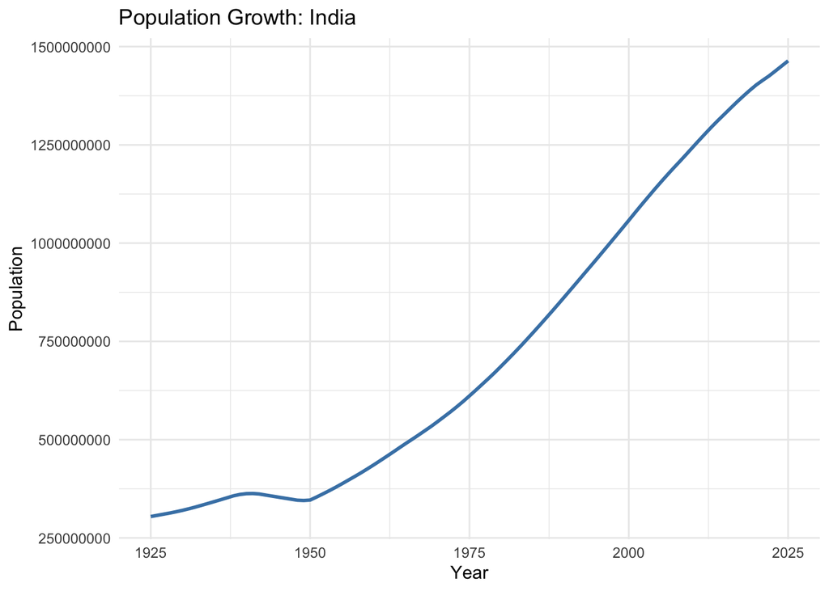

```r
top_country <- pop_growth_top5 %>%
  slice_head(n = 1) %>%
  pull(country)

gapminder %>%
  filter(country == top_country) %>%
  ggplot(aes(year, pop)) +
  geom_line(color = "steelblue", linewidth = 1) +
  labs(
    title = paste("Population Growth:", top_country),
    x = "Year",
    y = "Population"
  ) +
  theme_minimal()
```

5. Has global life expectancy changed between 1925 and 2025? Show the min, median, mean, and max for all countries (combined) in the dataset.

```r
gapminder %>%
  filter(year %in% c(1925, 2025)) %>%
  group_by(year) %>%
  summarize(
    min_lex = min(lex, na.rm = TRUE),
    median_lex = median(lex, na.rm = TRUE),
    mean_lex = mean(lex, na.rm = TRUE),
    max_lex = max(lex, na.rm = TRUE),
    .groups = "drop"
  )
```

```
## # A tibble: 2 × 5
##    year min_lex median_lex mean_lex max_lex
##   <dbl>   <dbl>      <dbl>    <dbl>   <dbl>
## 1  1925    21.0       35.9     38.1    63.5
## 2  2025    52.8       74.8     73.9    85.6
```

6. Make a plot that shows the distribution of life expectancy for all countries in 1925 and 2025 (try using `geom_density`). What do you notice about the shift in life expectancy over time?

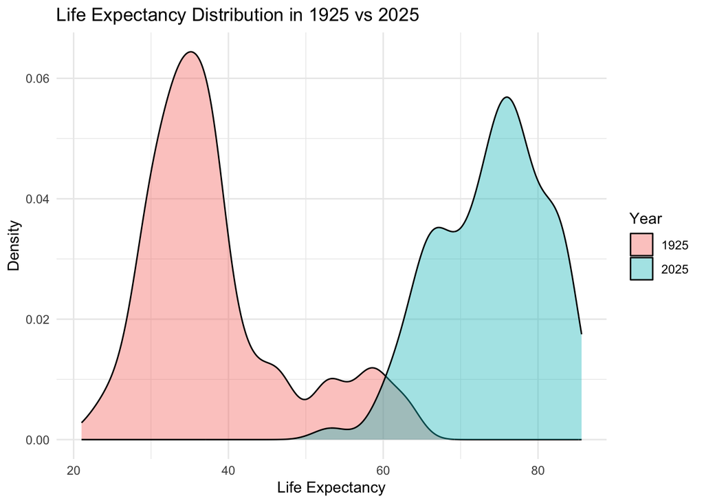

```r
gapminder %>%
  filter(year %in% c(1925, 2025)) %>%
  ggplot(aes(lex, fill = factor(year))) +
  geom_density(alpha = 0.4) +
  labs(
    title = "Life Expectancy Distribution in 1925 vs 2025",
    x = "Life Expectancy",
    y = "Density",
    fill = "Year"
  ) +
  theme_minimal()
```

7. We are interested in the relationship between per capita GDP and life expectancy; i.e. does having more money help you live longer in 2025? Show this as a plot. (Suggestion! Remove Monaco as an extreme outlier.)

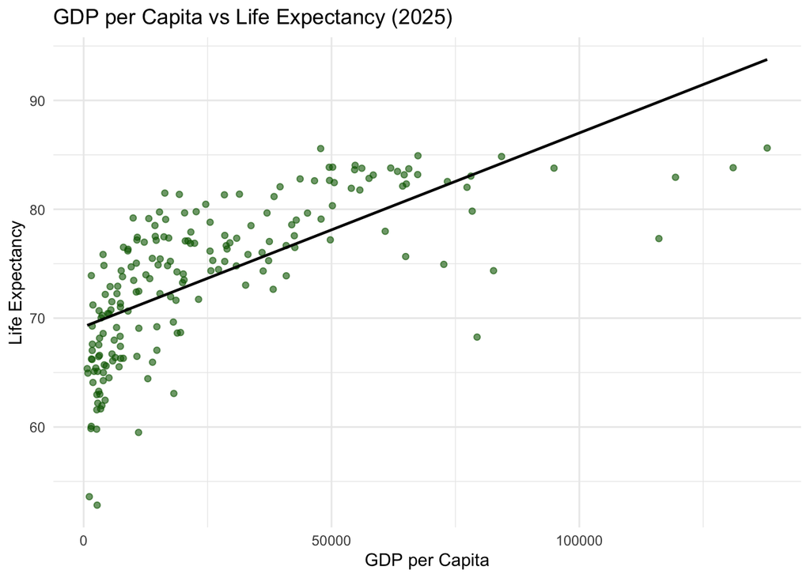

```r
gapminder %>%
  filter(year == 2025, country != "Monaco") %>%
  ggplot(aes(gdp, lex)) +
  geom_point(alpha = 0.6, color = "darkgreen") +
  geom_smooth(method = "lm", se = FALSE, color = "black", linewidth = 0.8) +
  labs(
    title = "GDP per Capita vs Life Expectancy (2025)",
    x = "GDP per Capita",
    y = "Life Expectancy"
  ) +
  theme_minimal()
```

8. Which five countries have had the highest absolute GDP per capita growth over the past 50 years? Show this as a table. (Suggestion! Remove Monaco as an extreme outlier.)

```r
gdp_growth_top5 <- gapminder %>%
  filter(year %in% c(1975, 2025), country != "Monaco") %>%
  select(country, year, gdp) %>%
  pivot_wider(names_from = year, values_from = gdp, names_prefix = "year_") %>%
  mutate(gdp_growth = year_2025 - year_1975,
         abs_gdp_growth = abs(gdp_growth)) %>%
  arrange(desc(abs_gdp_growth)) %>%
  slice_head(n = 5)

gdp_growth_top5
```

```
## # A tibble: 5 × 5
##   country    year_1975 year_2025 gdp_growth abs_gdp_growth
##   <chr>          <dbl>     <dbl>      <dbl>          <dbl>
## 1 Singapore     12896.   137906.    125010.        125010.
## 2 Ireland       14336.   119406.    105071.        105071.
## 3 Luxembourg    30950.   131038.    100088.        100088.
## 4 Guyana         5071.    79371.     74300.         74300.
## 5 Norway        25513.    94896.     69382.         69382.
```

9. How does per capita GDP growth compare between these same five countries over the past 50 years? Show this as a plot.

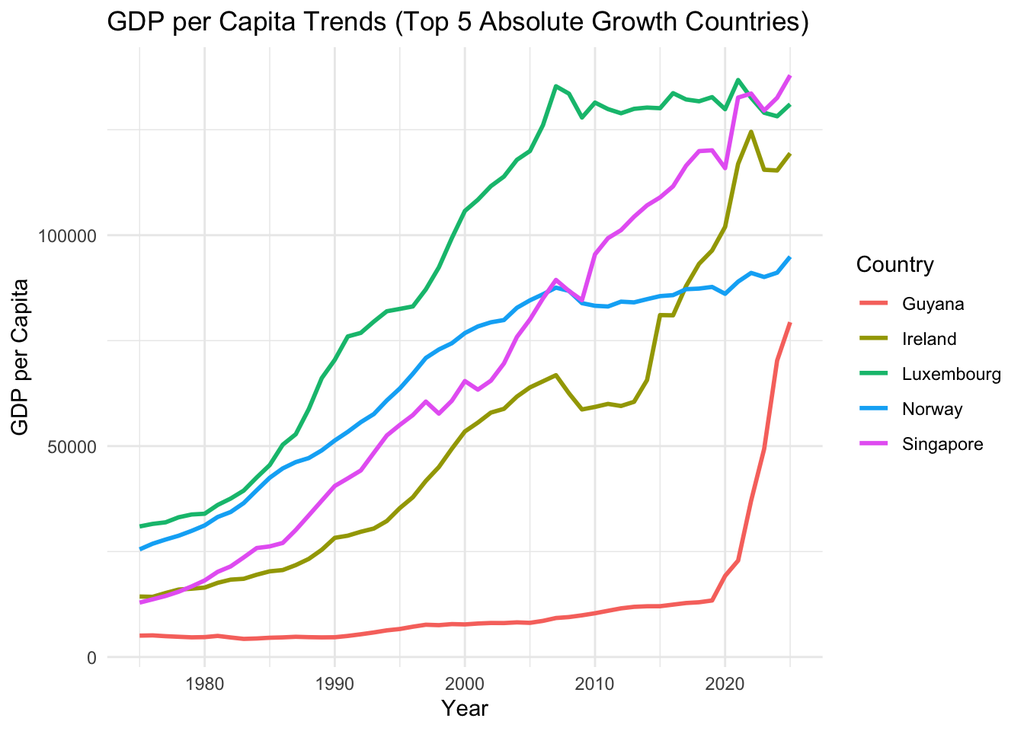

```r
top5_gdp_countries <- gdp_growth_top5 %>%
  pull(country)

gapminder %>%
  filter(year >= 1975, country %in% top5_gdp_countries) %>%
  ggplot(aes(year, gdp, color = country)) +
  geom_line(linewidth = 1) +
  labs(
    title = "GDP per Capita Trends (Top 5 Absolute Growth Countries)",
    x = "Year",
    y = "GDP per Capita",
    color = "Country"
  ) +
  theme_minimal()
```

10. Do one analysis of your choice that includes a table and plot as outputs.

```r
lex_growth_table <- gapminder %>%
  filter(year %in% c(1975, 2025)) %>%
  select(country, year, lex) %>%
  pivot_wider(names_from = year, values_from = lex, names_prefix = "year_") %>%
  mutate(lex_growth = year_2025 - year_1975) %>%
  arrange(desc(lex_growth)) %>%
  slice_head(n = 10)

lex_growth_table
```

```
## # A tibble: 10 × 4
##    country     year_1975 year_2025 lex_growth
##    <chr>           <dbl>     <dbl>      <dbl>
##  1 Cambodia         24.7      71.0       46.4
##  2 Maldives         51.7      80.5       28.8
##  3 Ethiopia         43.2      70.7       27.5
##  4 Bangladesh       50.6      76.3       25.7
##  5 Lao              45.5      70.6       25.1
##  6 Rwanda           45.0      70.0       25
##  7 Timor-Leste      47.2      72.2       25.0
##  8 Eritrea          40.7      65.4       24.8
##  9 Bhutan           51.0      74.8       23.8
## 10 Myanmar          47.0      70.8       23.7
```

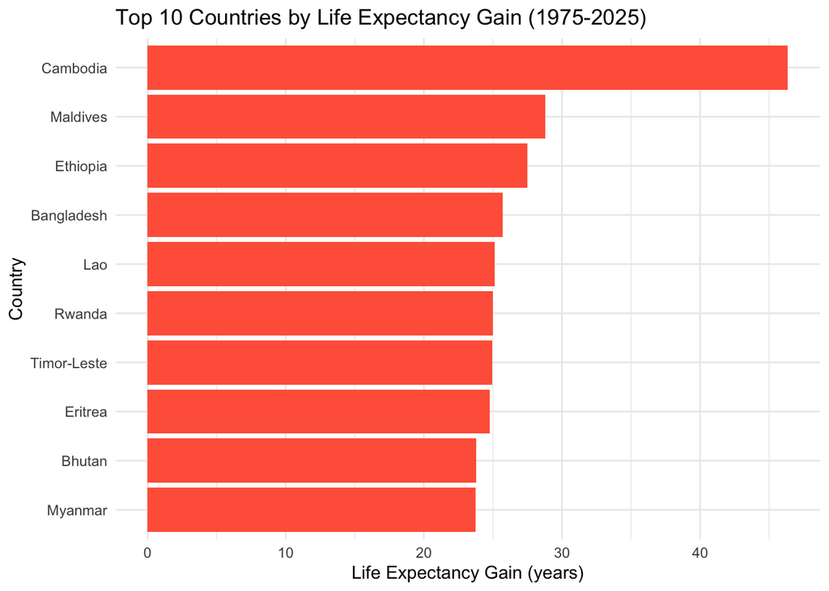

```r
lex_growth_table %>%
  ggplot(aes(reorder(country, lex_growth), lex_growth)) +
  geom_col(fill = "tomato") +
  coord_flip() +
  labs(
    title = "Top 10 Countries by Life Expectancy Gain (1975-2025)",
    x = "Country",
    y = "Life Expectancy Gain (years)"
  ) +
  theme_minimal()
```

## Additional Comprehensive EDA

The analyses below add common EDA checks that are usually done before modeling or interpretation.

11. Data quality checks: missingness, duplicate country-year rows, and year coverage by country.

```r
quality_summary <- gapminder %>%
  summarize(
    n_rows = n(),
    n_columns = ncol(gapminder),
    n_countries = n_distinct(country),
    min_year = min(year, na.rm = TRUE),
    max_year = max(year, na.rm = TRUE)
  )

missing_summary <- gapminder %>%
  summarize(across(everything(), ~sum(is.na(.)))) %>%
  pivot_longer(
    cols = everything(),
    names_to = "variable",
    values_to = "missing_n"
  ) %>%
  mutate(missing_pct = 100 * missing_n / nrow(gapminder)) %>%
  arrange(desc(missing_n))

duplicate_country_year <- gapminder %>%
  count(country, year) %>%
  filter(n > 1)

country_year_coverage <- gapminder %>%
  group_by(country) %>%
  summarize(n_years = n_distinct(year), .groups = "drop")

quality_summary
```

```
## # A tibble: 1 × 5
##   n_rows n_columns n_countries min_year max_year
##    <int>     <int>       <int>    <dbl>    <dbl>
## 1  19695         5         195     1925     2025
```

```r
missing_summary
```

```
## # A tibble: 5 × 3
##   variable missing_n missing_pct
##   <chr>        <int>       <dbl>
## 1 lex            357       1.81
## 2 gdp            202       1.03
## 3 pop             25       0.127
## 4 country          0       0
## 5 year             0       0
```

```r
duplicate_country_year
```

```
## # A tibble: 0 × 3
## # ℹ 3 variables: country <chr>, year <dbl>, n <int>
```

```r
country_year_coverage %>% summarize(min_years = min(n_years), max_years = max(n_years))
```

```
## # A tibble: 1 × 2
##   min_years max_years
##       <int>     <int>
## 1       101       101
```

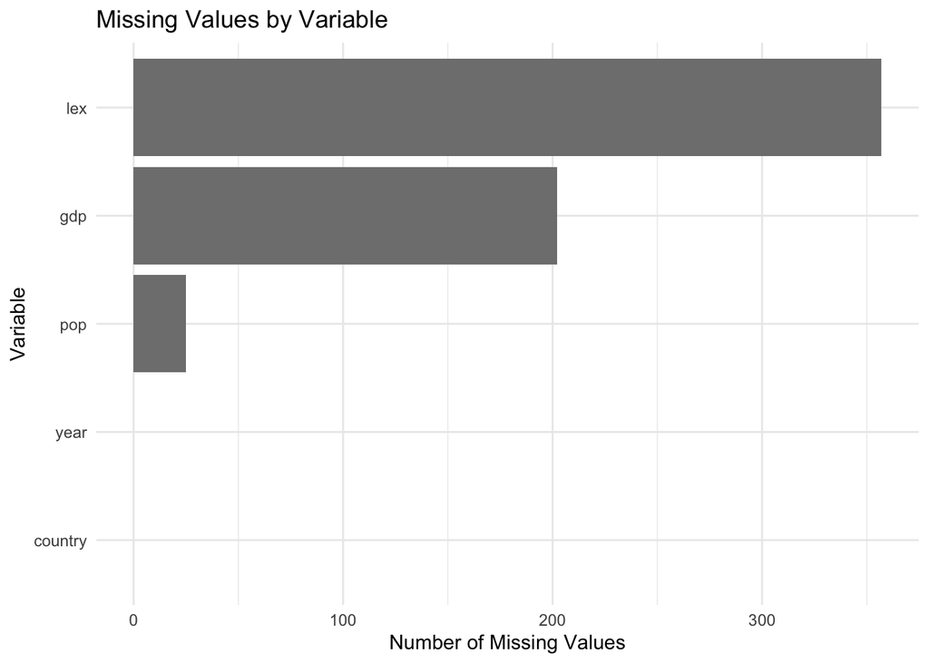

```r
missing_summary %>%
  ggplot(aes(reorder(variable, missing_n), missing_n)) +
  geom_col(fill = "gray50") +
  coord_flip() +
  labs(
    title = "Missing Values by Variable",
    x = "Variable",
    y = "Number of Missing Values"
  ) +
  theme_minimal()
```

12. Numeric distribution summary and potential outliers in 2025 using the IQR rule.

```r
numeric_summary <- gapminder %>%
  summarize(
    across(
      c(pop, gdp, lex),
      list(
        min = ~min(., na.rm = TRUE),
        q1 = ~quantile(., 0.25, na.rm = TRUE),
        median = ~median(., na.rm = TRUE),
        mean = ~mean(., na.rm = TRUE),
        q3 = ~quantile(., 0.75, na.rm = TRUE),
        max = ~max(., na.rm = TRUE),
        sd = ~sd(., na.rm = TRUE)
      )
    )
  ) %>%
  pivot_longer(
    cols = everything(),
    names_to = c("variable", ".value"),
    names_sep = "_"
  )

outliers_2025 <- gapminder %>%
  filter(year == 2025) %>%
  select(country, pop, gdp, lex) %>%
  pivot_longer(cols = c(pop, gdp, lex), names_to = "variable", values_to = "value") %>%
  group_by(variable) %>%
  mutate(
    q1 = quantile(value, 0.25, na.rm = TRUE),
    q3 = quantile(value, 0.75, na.rm = TRUE),
    iqr = q3 - q1,
    lower = q1 - 1.5 * iqr,
    upper = q3 + 1.5 * iqr,
    is_outlier = value < lower | value > upper
  ) %>%
  ungroup() %>%
  filter(is_outlier) %>%
  arrange(variable, desc(value)) %>%
  select(variable, country, value, lower, upper)

numeric_summary
```

```
## # A tibble: 3 × 8
##   variable    min       q1    median       mean         q3          max       sd
##   <chr>     <dbl>    <dbl>     <dbl>      <dbl>      <dbl>        <dbl>    <dbl>
## 1 pop      651    741871.  3915338.  22712317.  12044477   1463865525     9.54e7
## 2 gdp      316.     2124.     4661.     12054.     13082.      475911.    2.17e4
## 3 lex        4.18     48.1      61.9       59.2       70.9         85.6   1.44e1
```

```r
outliers_2025
```

```
## # A tibble: 26 × 5
##    variable country           value       lower      upper
##    <chr>    <chr>             <dbl>       <dbl>      <dbl>
##  1 gdp      Monaco         475911.     -44812.     90281.
##  2 gdp      Singapore      137906.     -44812.     90281.
##  3 gdp      Luxembourg     131038.     -44812.     90281.
##  4 gdp      Ireland        119406.     -44812.     90281.
##  5 gdp      Qatar          116057.     -44812.     90281.
##  6 gdp      Norway          94896.     -44812.     90281.
##  7 lex      Lesotho            52.8        52.9       94.8
##  8 pop      India      1463865525   -43724636   78608214
##  9 pop      China      1416096094   -43724636   78608214
## 10 pop      USA         347275807   -43724636   78608214
## # ℹ 16 more rows
```

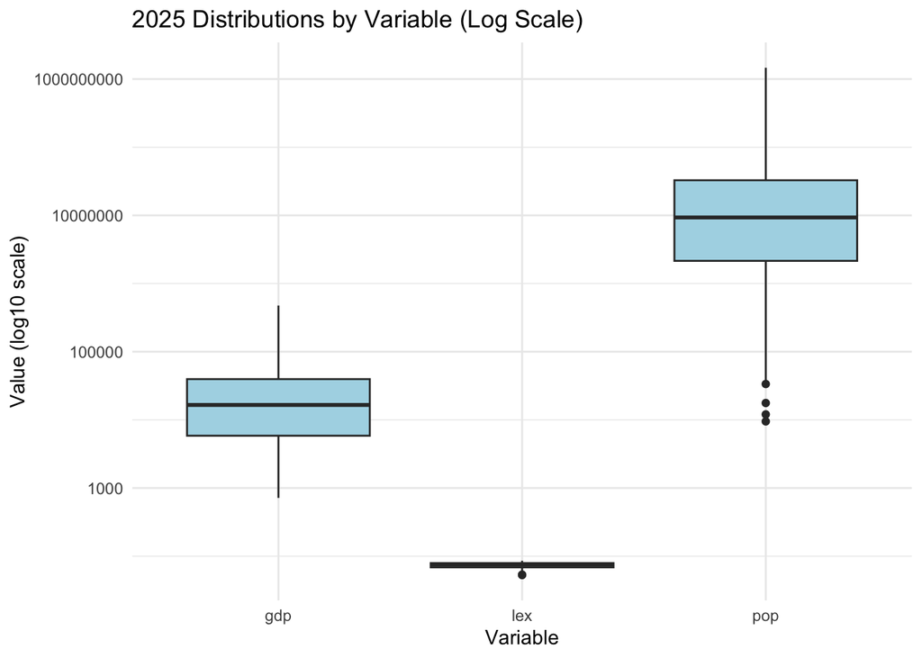

```r
gapminder %>%
  filter(year == 2025) %>%
  pivot_longer(cols = c(pop, gdp, lex), names_to = "variable", values_to = "value") %>%
  ggplot(aes(x = variable, y = value)) +
  geom_boxplot(fill = "lightblue") +
  scale_y_log10() +
  labs(
    title = "2025 Distributions by Variable (Log Scale)",
    x = "Variable",
    y = "Value (log10 scale)"
  ) +
  theme_minimal()
```

13. Global trends over time (population, weighted life expectancy, and median GDP per capita).

```r
global_yearly <- gapminder %>%
  group_by(year) %>%
  summarize(
    global_population = sum(pop, na.rm = TRUE),
    weighted_mean_lex = weighted.mean(lex, pop, na.rm = TRUE),
    median_gdp = median(gdp, na.rm = TRUE),
    .groups = "drop"
  )

global_yearly
```

```
## # A tibble: 101 × 4
##     year global_population weighted_mean_lex median_gdp
##    <dbl>             <dbl>             <dbl>      <dbl>
##  1  1925        1965415847              40.2      1999.
##  2  1926        1982851730              40.7      2071.
##  3  1927        2000538108              39.2      2129.
##  4  1928        2018498174              41.5      2191.
##  5  1929        2037115392              40.6      2284.
##  6  1930        2056439755              42.2      2315.
##  7  1931        2076473021              42.5      2320.
##  8  1932        2097208807              42.6      2254.
##  9  1933        2118603025              41.7      2282.
## 10  1934        2140276958              43.8      2309.
## # ℹ 91 more rows
```

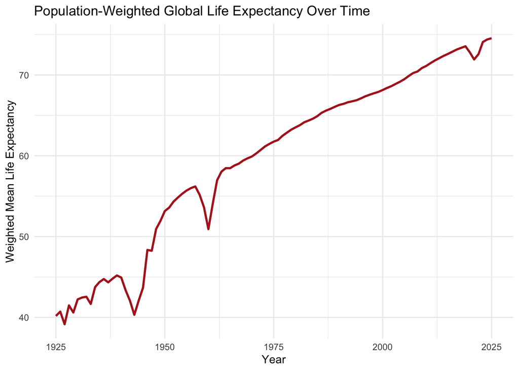

```r
global_yearly %>%
  ggplot(aes(year, weighted_mean_lex)) +
  geom_line(color = "firebrick", linewidth = 1) +
  labs(
    title = "Population-Weighted Global Life Expectancy Over Time",
    x = "Year",
    y = "Weighted Mean Life Expectancy"
  ) +
  theme_minimal()
```

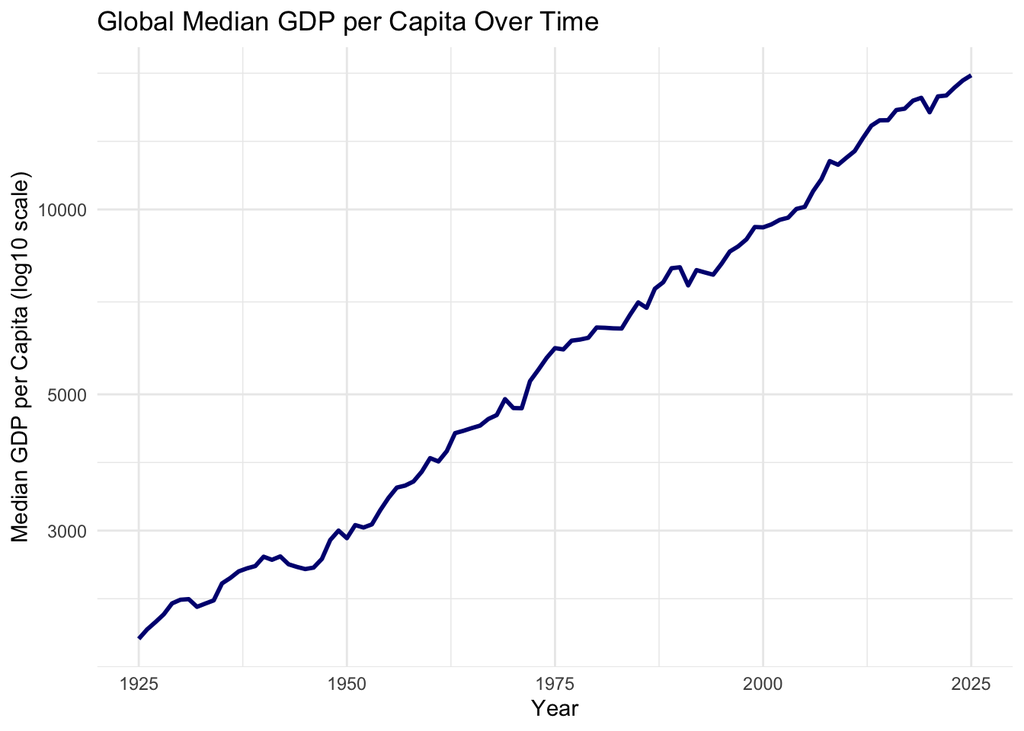

```r
global_yearly %>%
  ggplot(aes(year, median_gdp)) +
  geom_line(color = "navy", linewidth = 1) +
  scale_y_log10() +
  labs(
    title = "Global Median GDP per Capita Over Time",
    x = "Year",
    y = "Median GDP per Capita (log10 scale)"
  ) +
  theme_minimal()
```

14. Relationship diagnostics: how the GDP-life expectancy correlation changes over time.

```r
correlation_by_year <- gapminder %>%
  filter(gdp > 0) %>%
  group_by(year) %>%
  summarize(
    cor_log10gdp_lex = cor(log10(gdp), lex, use = "complete.obs"),
    .groups = "drop"
  )

correlation_by_year
```

```
## # A tibble: 101 × 2
##     year cor_log10gdp_lex
##    <dbl>            <dbl>
##  1  1925            0.665
##  2  1926            0.669
##  3  1927            0.691
##  4  1928            0.686
##  5  1929            0.687
##  6  1930            0.688
##  7  1931            0.663
##  8  1932            0.646
##  9  1933            0.599
## 10  1934            0.710
## # ℹ 91 more rows
```

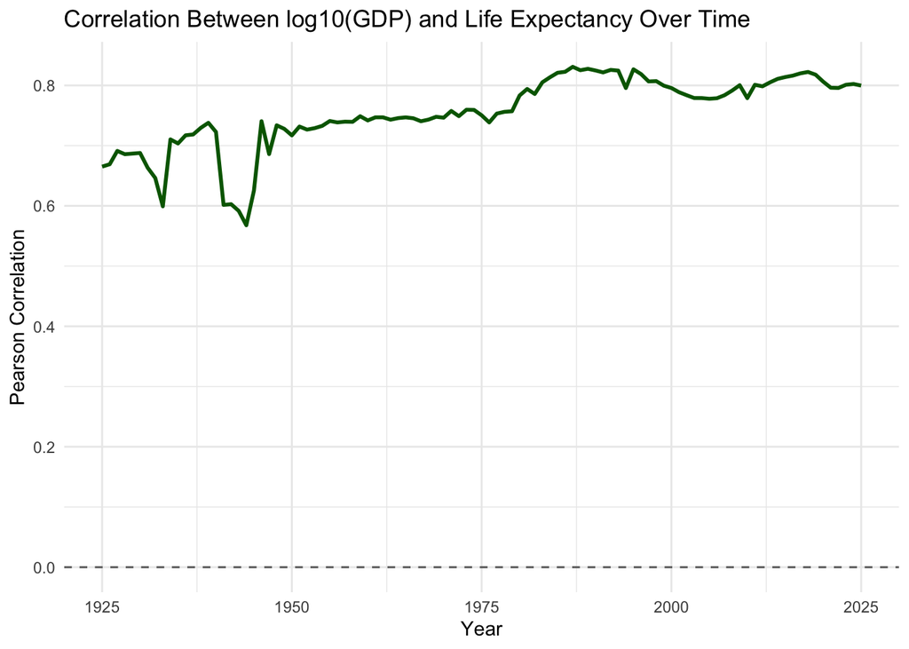

```r
correlation_by_year %>%
  ggplot(aes(year, cor_log10gdp_lex)) +
  geom_line(color = "darkgreen", linewidth = 1) +
  geom_hline(yintercept = 0, linetype = "dashed", color = "gray40") +
  labs(
    title = "Correlation Between log10(GDP) and Life Expectancy Over Time",
    x = "Year",
    y = "Pearson Correlation"
  ) +
  theme_minimal()
```

## Knit and Upload

Please knit your work as an .html file and upload to Canvas. Homework is due before the start of the next lab. No late work is accepted. Make sure to use the formatting conventions of RMarkdown to make your report neat and clean!